# Watersheds Excercise 4

Cameron Tenner

10/18/2020

# P1. Evaporation and Combination Equations

First we load in the dataset.

```r
obregon <- read.xlsx("P1_data.xlsx")
#notes on units
  # T = C
  # RH = %
  # Rn = Mj/m2/day
  # Precip = mm
  # V = m/s
head(obregon)
```

```
##   Year Julian.Day   Ta   RH       Rn Precip  Va
## 1 1997        274 30.7 67.8 15.84535     NA 1.8
## 2 1997        275 30.9 67.3 15.62292     NA 1.9
## 3 1997        276 30.6 68.3 15.87603     NA 2.4
## 4 1997        277 30.5 66.6 14.94029     NA 1.9
## 5 1997        278 29.7 65.7 15.03233     NA 3.2
## 6 1997        279 28.5 64.6 15.92972   0.25 2.6
```

We’re going to analyze April, which is Julian days 91-120

```r
april <- obregon %>% filter(Julian.Day >= 91 & Julian.Day <= 120)
head(april)
```

```
##   Year Julian.Day   Ta   RH       Rn Precip  Va
## 1 1998         91 15.6 61.3 20.03317     NA 2.1
## 2 1998         92 16.9 61.4 19.51928     NA 3.1
## 3 1998         93 16.8 57.0 20.29395     NA 1.7
## 4 1998         94 16.5 62.4 20.19424     NA 1.6
## 5 1998         95 17.7 63.0 19.92579     NA 1.7
## 6 1998         96 18.1 61.3 19.65734     NA 2.4
```

```r
NROW(april)
```

```
## [1] 30
```

Whole month had no rain, so I’m going to drop the precipitation column. I also add a day of April variable.

```r
april <- april %>% select (-Precip) %>% mutate(
  Day = row_number()
)
```

### Penman/Combination: Free Water Surface Evaporation

Given our assumptions the Penman Combination Equation is as follows:
$$E_0 = \frac{1000\Delta}{\rho_w \lambda_v \left[\Delta + \gamma \right]} \left[R_n\right] + \frac{\gamma}{\Delta + \gamma}\frac{6.43\left[1+0.536\overline{u_1} \right]}{\lambda_v} e_s\left[1 - RH\right]$$
Known values:

- Rn
- Ta
- u1
- RH
- density of water = 997 kg/m^3
- gamma (psychrometric constant), = 0.066

We need to find:

- es (saturation vapor pressure), can find with T
- latent heat of vaporization, can find with T
- delta (sat vapor pres-temp gradient), can find with T and es
- E0 (estimated potential evaporation), can find with all above

```r
gamma = 0.066
rowater = 997

penman_combo <- april %>% mutate(
  es = 0.611 * exp(17.27*Ta/(237.3+ Ta)),
  lambdav = 2.501 - (2.361 * (10^-3) * Ta),
  delta = 4098*es/((Ta+237.3)^2),
  E0 = (1000 * delta* Rn / (rowater*lambdav*(delta + gamma))) + ((gamma / (delta + gamma)) * ((6.43 * es * (1-(RH/100)) * (1+(0.536 * Va))) / lambdav) ),
  first = (1000 * delta* Rn / (rowater*lambdav*(delta + gamma))),
  second = ((gamma / (delta + gamma)) * ((6.43 * es * (1-(RH/100)) * (1+(0.536 * Va))) / lambdav) )
  )
```

### Penman/Monteith

Given our assumptions the Penman Monteith Equation is as follows:
$$E_{rc} = \frac{1000\Delta}{\rho_w \lambda_v \left[\Delta + \gamma^* \right]} \left[R_n\right] + \frac{\gamma}{\Delta + \gamma^*}\frac{900}{\left[T_a + 275\right]} \overline{u_1}e_s\left[1 - RH\right]$$
Need to additionally find:

- gamma_star, can be found with gamma and u1
- Erc, can be found with all above info

```r
penman_mont <- april %>% mutate(
  es = 0.611 * exp(17.27*Ta/(237.3+ Ta)),
  lambdav = 2.501 - (2.361 * (10^-3) * Ta),
  delta = 4098*es/((Ta+237.3)^2),
  gamma_star = gamma * (1 + (0.33*Va)),
  Erc = (1000 * delta / (rowater*lambdav*(delta + gamma_star)) * Rn) + ((gamma / (delta + gamma_star)) * (900/(Ta+275)) * Va * es * (1-(RH/100))),
  #first =  (1000 * delta / (rowater*lambdav*(delta + gamma_star)) * Rn),
)
```

Now we join the two datasets together

```r
joined <- left_join(penman_combo, penman_mont, by = "Day")
joined_gather <- joined %>% select(Day, E0, Erc) %>% gather(key = "Type", value = "E", -Day)
```

Now we can graph results

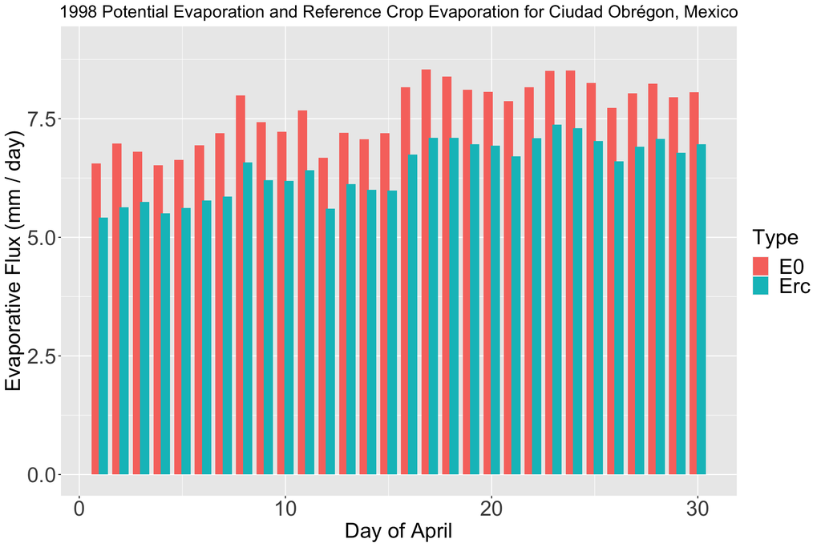

```r
ggplot(joined_gather, aes(x=Day, y=E, fill = Type)) + geom_col(position = position_dodge(width = .7)) + labs(title = "1998 Potential Evaporation and Reference Crop Evaporation for Ciudad Obrégon, Mexico", y = "Evaporative Flux (mm / day)", x = "Day of April") + ylim(0, 9) + theme(
        plot.title = element_text(hjust = 0.5, size = 18),
        axis.text.x = element_text( size = 22),
        axis.text.y = element_text(size = 22),
        axis.title.x = element_text(size = 22),
        axis.title.y = element_text(size = 22),
        legend.title = element_text(size = 22),
        legend.text = element_text(size = 22))
```

more graphs

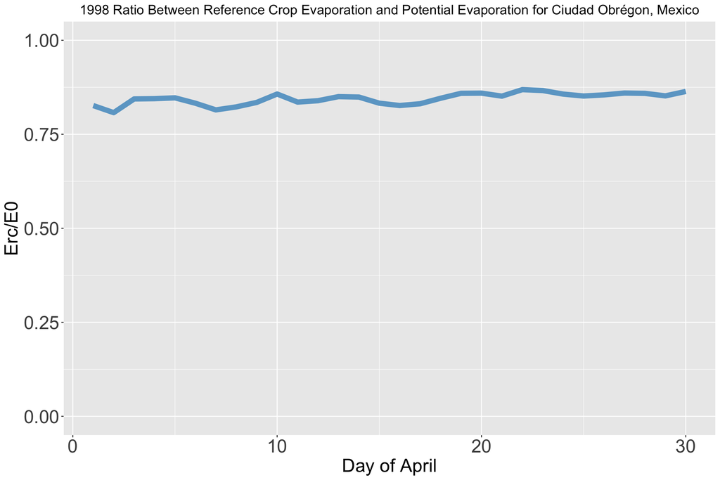

```r
joined <- joined %>% mutate(
  dif = Erc - E0,
  ratio = Erc/E0
)

# ggplot(joined, aes(x=Day, y=dif)) + geom_col(fill = "skyblue3", ) + labs(title = "1998 Difference Between Potential Evaporation and Reference Crop Evaporation for Ciudad Obrégon, Mexico", y = "∆ Evaporative Flux (mm / day)", x = "Day of April")  +
#   theme(plot.title = element_text(hjust = 0.5, size = 16),
#         axis.text.x = element_text( size = 22),
#         axis.text.y = element_text(size = 22),
#         axis.title.x = element_text(size = 22),
#         axis.title.y = element_text(size = 22))

ggplot(joined, aes(x=Day, y=ratio)) + geom_line(color = "skyblue3", size=3) + labs(title = "1998 Ratio Between Reference Crop Evaporation and Potential Evaporation for Ciudad Obrégon, Mexico", y = "Erc/E0", x = "Day of April") +
  theme(plot.title = element_text(hjust = 0.5, size = 16),
        axis.text.x = element_text( size = 22),
        axis.text.y = element_text(size = 22),
        axis.title.x = element_text(size = 22),
        axis.title.y = element_text(size = 22)) + ylim(0,1)
```

# P3. ET & Crop Coefficients

```r
Pajaro <- read.csv("P3_data.csv") %>%
  mutate(
    month = format(as.Date(Date, "%m/%d/%y"), "%b"),
    month_day = format(as.Date(Date, "%m/%d/%y"), "%m/%d")
  )
Pajaro$Date <- as.Date(Pajaro$Date, "%m/%d/%y")

Pajaro$month_day <- as.Date(Pajaro$month_day, format = "%m/%d")
```

First we need to assign a stage to each date

```r
Pajaro <- Pajaro %>% mutate(
    stage = case_when(
      month == "May" ~ "1",
      month_day > as.Date("5/31", "%m/%d") &  month_day < as.Date("7/11", "%m/%d") ~ "2",
      month_day > as.Date("2/29", "%m/%d") & month_day < as.Date("4/1", "%m/%d") ~ "4",
      month_day < as.Date("3/1", "%m/%d") ~ "3",
      month_day > as.Date("7/10", "%m/%d") ~ "3"#,
      #month == "Apr" ~ "Fallow"
    )
  )
```

To make the Kco interpolation easier, I’m reordering the dataset to go from day 1 stage 1 to day 30 fallow (May to April)

```r
start <- Pajaro[214:366,]
end <- Pajaro[1:213,]

pajaro_growing_season <- rbind(start,end)
```

Now we need to make a vector that interpolates Kco over the growing season

Stage 1 We need to find Kco using the average Erc for stage 1

```r
mean((pajaro_growing_season %>% filter(stage == 1))$Eto)
```

```
## [1] 4.752903
```

Using fig 4.4.2, Kco = 0.23 during stage 1

```r
stage1 <- rep.int(.23, NROW(pajaro_growing_season %>% filter(stage == 1)))
```

Stage 3 Kco varies with wind speed and min RH Lets tak a look at wind speed

```r
max((pajaro_growing_season %>% filter(stage == 3))$Avg.Wind.Speed)
```

```
## [1] 3.6
```

The maximum wind speed recorded on period 3 days was less than 5 m/s, so we only need to worry about RH variability.

Now lets take a look at RH

```r
max((pajaro_growing_season %>% filter(stage == 3))$Avg.Rel.Hum, na.rm = T)
```

```
## [1] 97
```

```r
min((pajaro_growing_season %>% filter(stage == 3))$Avg.Rel.Hum, na.rm = T)
```

```
## [1] 28
```

```r
mean((pajaro_growing_season %>% filter(stage == 3))$Avg.Rel.Hum, na.rm = T)
```

```
## [1] 79.0198
```

The minimum value of RH is above 20%, but not above 70%, so we find ourselves in an interesting “in between” which we are not given explicit guidance for. Luckily, the range of choices we have for our Kco for stage 3 is relatively small: between 0.95 and 1.0. In this instance, I propose we assign a Kco of .975, as it is square in the middle of the range. Because the range is so small, this choice should not have a huge impact on our outcome.

```r
stage3 <- rep.int(.975, NROW(pajaro_growing_season %>% filter(stage == 3)))
```

Stage 2 Interpolate between Kco for 1 and Kco for 3. We will be using a straight line to interpolate.

```r
stage2 <- seq(from = .23, to = .975, length.out = NROW(pajaro_growing_season %>% filter(stage == 2)))
```

Stage 4 Interpolate between Kco for 3 and Kco after stage 4. I’m choosing to use a Kco at the end of stage 4 of 0.925, for the same reason we chose 0.975 for stage 3.

```r
stage4 <- seq(from = .975, to = .925, length.out = NROW(pajaro_growing_season %>% filter(stage == 4)))
```

Fallow I’m assigning 0 values for the fallow period to preserve the proper size of the vector

```r
fallow <- rep.int(0, 30)
```

Now we can assign this vector to a “Kco” column, and calculate consumptive use by multiplying Kco and Eto.

```r
allstages <- c(stage1, stage2, stage3, stage4, fallow)
pajaro_growing_season <- pajaro_growing_season %>% mutate(
  Kco = NA
)
pajaro_growing_season$Kco <- allstages

pajaro_growing_season <- pajaro_growing_season %>% mutate(
  consumptive_use = Kco * Eto,
  day_of_growing_season = row_number()
)
```

Before we can visualize the results we need to revert back to water year ordering and fix the date field.

```r
start <- pajaro_growing_season[154:366,]
end <- pajaro_growing_season[1:153,]

pajaro_WY <- rbind(start, end)

pajaro_WY$Date <- as.Date(pajaro_WY$Date, format = "%m/%d/%y")
```

Now we can plot consumptive use over WY 2020.

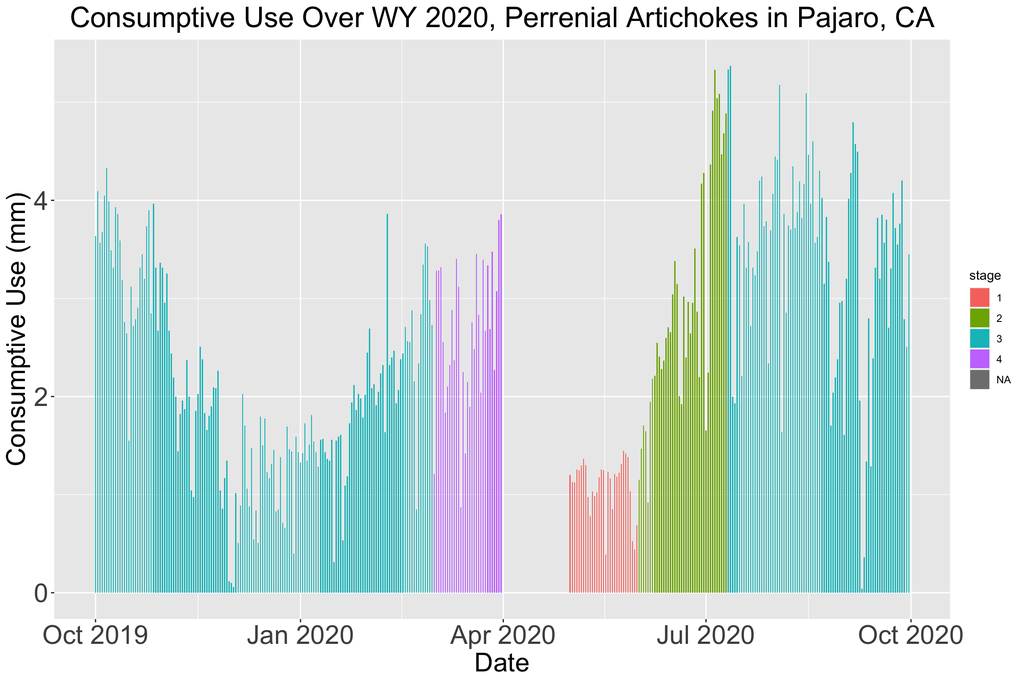

```r
ggplot(pajaro_WY, aes(x=Date, y=consumptive_use, fill = stage)) + geom_col(width = .5) + labs(title = "Consumptive Use Over WY 2020, Perrenial Artichokes in Pajaro, CA", y = "Consumptive Use (mm)") +
  theme(plot.title = element_text(hjust = 0.5, size = 24),
        axis.text.x = element_text( size = 22),
        axis.text.y = element_text(size = 22),
        axis.title.x = element_text(size = 22),
        axis.title.y = element_text(size = 22))
```